# A quick tour of your web data

#### By Eric Foster-Moore

The figure below is a network diagram of your web traffic data. Although that ultimately proved to be the least fruitful path of inquiry that I pursued, it did make the prettiest picture. In the rest of this notebook, I explain my goals for this exercise and then dive into data cleaning, doing some preliminary network analysis of your data, and then finally implementing a simple recommendation engine using the `Surprise` library.

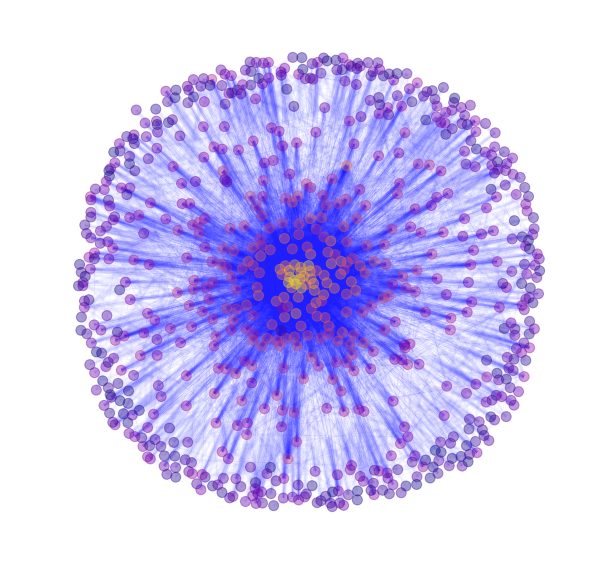

```python
fig1
```

## Questions driving this analysis

### Big questions from S&P:

- How are users using the products
- Recommend unseen web pages that are likely to be of value

### More specific questions from S&P:

- What general patterns do you observe in the data?
- Do you observe any logical groupings of users? If so, how did you identify them?
- Do you observe any logical groupings of pages? If so, how did you identify them?
- Are there any pages or users you might choose to exclude from your analysis? If so, which ones and why?
- One of our Product Managers would like to know which pages are most similar to page595 , Physical Survey. From the data, can you identify other highly related pages? How do you do so?
- One of our Account Managers is planning a visit with user482. She would like to recommend a few pages to the user which they aren’t using yet, but might find interesting. From the data, can you identify new pages that are likely to be interesting to this particular user? How? Could this process be done for additional users in an automated way?
- What documentation, references, and other resources did you use to help you with this challenge?

## Things I learned

Most of what I do in this notebook I taught myself in the last couple days (namely, network theory and recommendation engine theory using `Surprise`). Although I counsulted the internet extensively, I did not interactively consult with any other humans. I certainly haven't mastered the techniques I settled on, but I did get the basics down and hopefully have outlined where this work could go in the future.

Here are some of the specific things that I learned:

#### 1. What web traffic data looks like.

This might be surprising given that it's 2018 but I've never actually worked with page view data before.

#### 2. What page rank is and how to calculate

I've heard about the Google page rank algorithm, but I've never actually used it before. I learned that the page rank reflects the number of pages that link to a given page.

#### 3. How to represent web traffic data as a network (graph)

I learned about how network data is structured, how to convert the page view data you sent me into a list of edges, and then how to display that as an actual directional network graph.

#### 4. What recommendations engines are

I learned about the difference between content filtering and collaborative filtering. I recognized that content filtering would not work with this data (there may be some exceptions there since it might be possible to extract some latent features from the user and page view data, but I didn't explore this). Collaborative filtering calculates the similarity between users (user-user similarity) or items (item-item similarity). To do this you basically need to create a matrix with users as rows and items as columns and cells containing item ratings (or, in our case, page views or page rank).

#### 5. How to create a user-item rating matrix

I was going to go down the "Let's build a recommendation engine by hand" rabbit hole, so I figured out how to create a user-item matrix with number of page views as the cell values. This turned out to be the wrong approach because I ultimately came across the `Surprise` library and found out that someone had done a lot of this work already.

#### 6. How to use `Surprise`

Surprise lets you take a dataframe with the columns `user`, `item`, and `rating`, and basically does all the heavy lifting on the fly. Presumably this includes creating a user-item matrix on the fly and then computing measures of similiarity between either items or users.

## Now for the actual work

```python
import os
import sys

import pandas as pd
import numpy as np
from matplotlib import pyplot as plt

import random
import wget

from datetime import date
import networkx as nx
from collections import defaultdict

from surprise import BaselineOnly
from surprise import Dataset
from surprise import Reader
from surprise import KNNBasic
from surprise import accuracy
from surprise.model_selection import cross_validate

# - I should have a requirements file in here to, I know
## - denotes something that I need to address (i.e. quickly search the page for '##' to find lingering issues)

%matplotlib inline
```

### Setup and cleaning

```python
# Set up directories
RAW = os.path.join('..', 'rawdata')
SCRATCH = os.path.join('..', 'rawdata')
```

```python
# Load data
page_names = pd.read_csv(os.path.join(RAW, 'page_names.csv'))
page_usage = pd.read_csv(os.path.join(RAW, 'page_usage.csv'))
```

```python
raw_page_usage_length = len(page_usage)
print('Page_names df shape is: ', page_names.shape)
print('Page_usage df shape is: ', page_usage.shape)
```

```
Page_names df shape is:  (741, 2)
Page_usage df shape is:  (617256, 4)
```

```python
# Convert column names to lowercase

dataframes = [page_names, page_usage]

for df in dataframes:
    df.columns = df.columns.str.lower()
```

```python
# Check for missing data (## strip blanks?)

print(page_names.isnull().values.any())
print(page_usage.isnull().values.any())
```

```
False
False
```

```python
# Check for duplicate page IDs in page_names:

print('Number of rows: ', len(page_names))
print('Unique page IDs: ', page_names.pageid.nunique())
print('Number of page names: :', page_names.name.nunique())

if page_names.pageid.nunique() != len(page_names):
    print('We have a problem: duplicated page IDs')
if page_names.name.nunique() != len(page_names):
    print('We may have a small problem: duplicated page names')
else:
    print('All good')
```

```
Number of rows:  741
Unique page IDs:  741
Number of page names: : 720
We may have a small problem: duplicated page names
```

```python
# So apparently there are some duplicated page names, but not duplicated page IDs.
# This could be a mistake in the data or it could be that there are actually different version of the same pages online

# Tag duplicate page names
page_names['name_dup'] = page_names.duplicated(subset='name', keep=False)
```

```python
# Let's take a quick look at some of those duplicates

'''
Looks like some could be errors resulting from erroneous naming conventions (e.g. the 'Article' pages) and some could be actual
duplicate pages. It's not immediately clear what the consequences of these duplicates. Putting a pin in this.
'''

# page_names.loc[page_names['name_dup'] == True].sort_values(by='name')
```

```
"\nLooks like some could be errors resulting from erroneous naming conventions (e.g. the 'Article' pages) and some could be actual\nduplicate pages. It's not immediately clear what the consequences of these duplicates. Putting a pin in this.\n"
```

```python
# Join page names to page usage
df = pd.merge(page_usage, page_names, on='pageid', how='left')

# Check that the join worked correctly

joined_length = len(df)

print('Raw page views length: ', raw_page_usage_length)
print('Joined length: ', joined_length)

if joined_length > raw_page_usage_length:
    print('Join problem')
else:
    print('Same number of rows')
```

```
Raw page views length:  617256
Joined length:  617256
Same number of rows
```

```python
# These are pages that I definitely want to drop
# I consider dropping additional pages later on

bad_page_names = [

    'New User Signup: Step 3',
    'New User Signup: Step 4',
    'Password',
    'Login'
]

# Candidates for bad page names to revisit:

'''
    'Universal Search Results',
    'Select-A-Page Search',
    'All Links',
    'Documents
'''

bad_user_names = [

    # This is where I'd eventually add in user names that I want to exclude. Leading candidates:

    '''
    'user480',
    'user1120',
    'user1129',
    '''
]
```

```python
# Count how many bad pages names I plan to drop:

print(df[df['name'].isin(bad_page_names)].name.value_counts())
total_pageviews_to_drop = df['name'].isin(bad_page_names).sum()
print('Total: ', total_pageviews_to_drop)
```

```
New User Signup: Step 3    2136
Login                      1541
New User Signup: Step 4    1348
Password                   1106
Name: name, dtype: int64
Total:  6131
```

```python
# Drop rows from the data frame where the page name is in the list of bad page names

print('Length before drop: ', len(df))

df = df[~df['name'].isin(bad_page_names)]

print('Length after drop: ', len(df))
print('Rows dropped: ', joined_length - len(df))
print('Rows to drop = rows actually dropped? ', (total_pageviews_to_drop == (joined_length - len(df))))
```

```
Length before drop:  617256
Length after drop:  611125
Rows dropped:  6131
Rows to drop = rows actually dropped?  True
```

```python
# Create a timestamp for page access

'''
The source data only contain day of year and time of day so I pick an arbitrary year
to base the creation of a date variable. There is probably an more elegant way to do this
but that's something to revisit.
'''

df['year'] = 2017 # Pick an arbitrary year to base day-of-year
df['date'] = pd.to_datetime(df['year'] * 1000 + df['day'], format='%Y%j') # Create a date variable
df['timestamp'] = df['date'].dt.date.map(str) + ' ' + df['time']          # Concatenate the two into a single datetime string
df['timestamp'] = pd.to_datetime(df['timestamp'])                         # Convert that string to a datetime object ## add the right mask

# Drop datetime artifacts
df.drop(['day', 'time', 'year', 'date', 'name_dup'], axis=1, inplace=True)
```

### First let's look at web traffic volume and growth in unique users

The goal here is to get a sense of site performance over time. Both page views and the number of unique users are increasing over time (generally good things). I will say however that the growth in unique users is suspiciously regular.

```
Text(0.5,0,'Date')
```

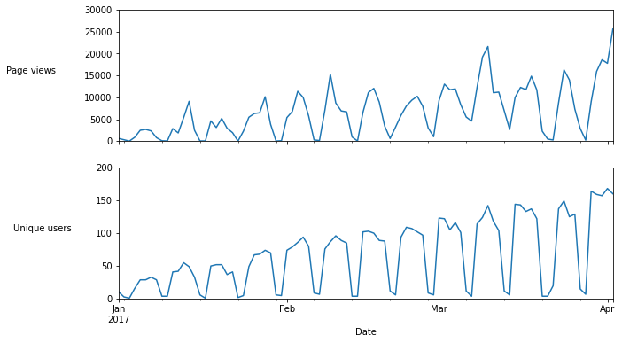

```python
# Quick plot of page views and unique users over time

fig, (ax1, ax2) = plt.subplots(nrows=2, ncols=1, sharex=True, figsize=(10,6))

ylabelrotation = 'horizontal'
ylabelpad = 60

df.groupby(pd.Grouper(key='timestamp', freq='D')).size().plot(ax=ax1)
ax1.set_ylabel('Page views', rotation=ylabelrotation, labelpad=ylabelpad)
ax1.set_ylim([0, 30000])

df.groupby(pd.Grouper(key='timestamp', freq='D')).userid.nunique().plot(ax=ax2)
ax2.set_ylabel('Unique users', rotation=ylabelrotation, labelpad=ylabelpad)
ax2.set_ylim([0, 200])

plt.xlabel('Date')
```

### Now let's look at the most active users and most frequently visited pages

Note the big difference in number of page views per user between the top three users and the rest of the users. Note also six pages dominate page views. We may want to consider excluding these users and pages from our analyses and models in the future, especially for all the news related pages which are probably landing-esque pages that serve up generic content. What we're really interested in is discovering low-visit pages that might be useful to users. Conversely, we may also want to consider dropping the users that have the least activity and the pages that have the least views.

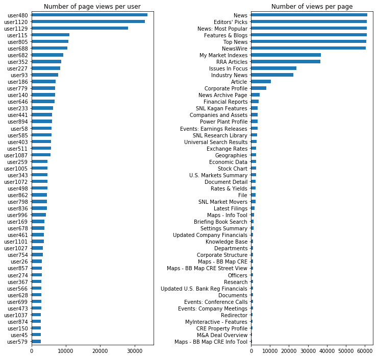

```python
# Plot biggest users and most frequently visited pages

fig, (ax1, ax2) = plt.subplots(ncols=2, nrows=1, sharex=False, figsize=(12,12))

df['userid'].value_counts()[:50].sort_values().plot(kind='barh',  title='Number of page views per user', ax=ax1)
df['name'].value_counts()[:50].sort_values().plot(kind='barh', title='Number of views per page', ax=ax2)

plt.subplots_adjust(wspace=0.8)
```

### About 44.5 percent of pages views are to news-related pages

These are pages we might want to consider excluding

```python
print('Percent of page views to pages that contain news in their title: ', df.name.str.lower().str.contains('news').sum()/len(df))
```

```
Percent of page views to pages that contain news in their title:  0.445103702189
```

## Network graphing

This is the first big area of analysis that I explored. It occurred to me that the pages of your site are a big network and that to understand how users use your products, it might make sense to look at how they move about from page to page--i.e. how they traverse the nodes of a network. My analysis is rudimentary, I'm not yet completely sure how to interpret the findings, and there are some important modifications I need to make to the network data, but I think this is a promising avenue of inquiry.

I also computed the page rank of all the pages in your dataset, which I do know how to interpret and which is immediately informative. I do this using the `networkx` library's `page_rank` method, which computes some version of the eigenvector for each page.

##### Sort by userid and timestamp

The first thing I do is sort the dataframe of pageviews by userid and then by timestamp. This returns an approximation of user sessions.

```python
# Sort data by userid then by timestamp
df.sort_values(by=['userid', 'timestamp'], ascending=True, inplace=True)
df.reset_index(inplace=True, drop=True)
```

##### Create a list of sequential page views

I then pull out a list of page views in the order they were viewed. I am ignoring for the moment the fact that these need to be separated into user-sessions. I'm not sure of the best way to do that so deferring for the moment.

```python
# Create list of page views
page_view_list = df['name'].tolist()
page_view_edges = []
```

##### Create list of edges (ordered pairs) in sequence

Network edges are represented as a list of ordered pairs of page views, e.g. in the tuple `('News', 'Article')`, the user went from the News page to the Article page. The next tuple in the sequence might be `('Article', 'Report')`. This is the data structure required by the `networkx` library.

```python
# Create a list of edges, which are ordered pairs of page views

for idx, elem in enumerate(page_view_list):
    thiselem = elem
    nextelem = page_view_list[(idx + 1) % len(page_view_list)]
    mytuple = (thiselem, nextelem)

    if thiselem != nextelem:
        page_view_edges.append(mytuple) # Excludes pages that refer back to themselves
```

```python
# Instantiate G, a directional graph object
G = nx.DiGraph()
```

```python
# Add edges to the graph from the list created above
G.add_edges_from(page_view_edges)
```

```python
# Compute the page rank of pages in the edge list
pr = nx.pagerank(G)
```

```python
# Create a dataframe out of the page rank values

page_rank = pd.DataFrame.from_dict(pr, orient='index').reset_index()
page_rank.rename(columns={'index': 'page', 0: 'page_rank'}, inplace=True)

# Display top 10 pages by page rank
page_rank[:10].sort_values(by='page_rank', ascending=False)
```

|  | page | page_rank |
| --- | --- | --- |
| 0 | News | 0.025716 |
| 8 | Article | 0.019479 |
| 5 | Features & Blogs | 0.017484 |
| 7 | Editors' Picks | 0.017120 |
| 1 | NewsWire | 0.015520 |
| 2 | Top News | 0.012840 |
| 3 | Issues In Focus | 0.012309 |
| 9 | RRA Articles | 0.009605 |
| 4 | News: Most Popular | 0.009101 |
| 6 | Industry News | 0.006920 |

##### Drawing a network graph

I'd never done this before so I was pretty excited when this worked. It took a little fiddling to find out how to make things pretty, and I'll admit this graph isn't actually all that useful yet. Each node is a page and there are lines connecting the page views, representing the sequence in which users traversed the page network. The pages in the center have the most views and I scaled the color values of the nodes by the natural log of the page rank. Since there are so many pages, I removed the labels from the nodes because they were impossible to read, but that would be useful at some point.

```
(-0.10499999374151231,
 1.1049999341368675,
 -0.10462956637144091,
 1.1011016270518303)
```

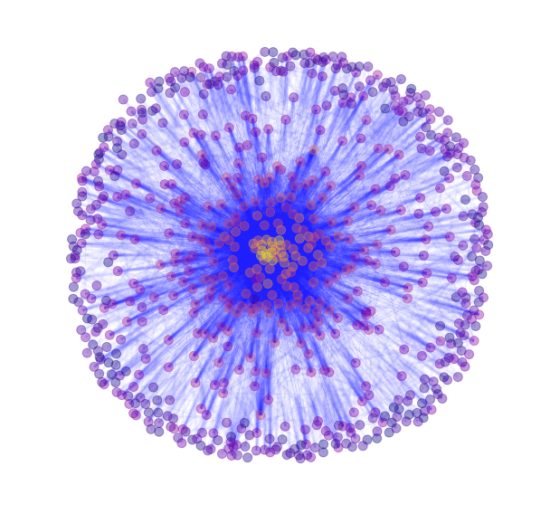

```python
# Draw a network graph and color the nodes by the natural log of the page rank

fig1, ax = plt.subplots(figsize=(10,10))

graph4 = nx.DiGraph()
graph4.add_edges_from(page_view_edges)

values = [pr.get(node) for node in graph4.nodes()]

pos = nx.spring_layout(graph4, k=.85)
nx.draw_networkx_edges(graph4, pos, edge_color='b', arrows=True, alpha=0.03)
nx.draw_networkx_nodes(graph4, pos, cmap=plt.get_cmap('plasma'), node_color=np.log(values), node_size=100, alpha=0.4)

plt.axis('off')
```

#### Now I want to compare page rank values with page views

News is still the top page in both cases, but some pages with fewer views rise to the top of the of the page rank list. There is also a less skewed distribution of page rank values. Later, when I predict which pages users might find useful, I initially use page views as the 'rating' metric. But it might make more sense to use page rank.

```python
page_rank.sort_values(by='page_rank', ascending=False, inplace=True)
top_pages = page_rank[['page', 'page_rank']][:50]
top_pages.set_index('page', inplace=True)
```

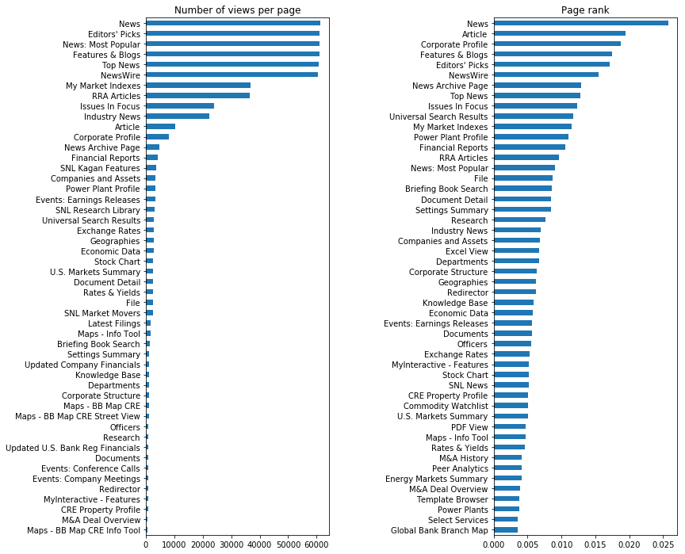

```python
fig, (ax1, ax2) = plt.subplots(ncols=2, nrows=1, sharex=False, figsize=(12,12))

df['name'].value_counts()[:50].sort_values().plot(kind='barh', title='Number of views per page', ax=ax1)
top_pages.sort_values(by='page_rank', ascending=True).plot(kind='barh', title='Page rank', ax=ax2, legend=None)

ax2.set_ylabel('')
plt.subplots_adjust(wspace=0.9)
```

## Building a simple recommendation engine

We want to use a collaborative filtering approach. Collaborative filtering calculates how similar two users are based on their vectors (of item ratings). A classic case is movie recommendations where users rate movies on a 1 to 5 star scale. We don't have ratings, but we do have page views and page rank.

#### Strategy 1

Since I've never actually done this before, my first strategy was to do it by hand. I created a user-page matrix and then was about the manually compute the cosine similarity of users/pages but then I realized there were easier ways to do this. However I'll leave this here for posterity.

```python
# Create a list of users
users = page_usage['userid'].drop_duplicates().tolist()
users.sort() ## Note that this does a poor job of sorting since 'userid' is a string
```

```python
# Initialize a dataframe that contains page names as the index
matrix = pd.DataFrame(page_names['name']).set_index('name')
```

```python
len(matrix) # Note that this includes some of the duplicate page names
```

```
741
```

```python
# Create the user-page matrix (this takes a while)

for user in users:
    user_page_views = pd.DataFrame(df.loc[df['userid'] == user]['name'].value_counts())
    user_page_views.rename(columns={'name': user}, inplace=True)
    matrix = pd.concat([matrix, user_page_views], axis=1)
```

```python
## Note that the matrix has lost 21 rows--720 is the number of page names, not page IDs. I don't *think* this is a problem.
matrix.shape
```

```
(720, 1138)
```

```python
# Replace NaN with zero (I was prepping the data for more math)
matrix.fillna(0, inplace=True)
```

### Strategy 2: use `Surprise`

Source documentation: https://surprise.readthedocs.io

```python
df.sort_values(by='userid', inplace=True)
```

```python
# Create a new dataframe that shows the count views for each page by user

ratings = df.groupby(['userid', 'name']).count().reset_index()
ratings.rename(columns={'pageid': 'count'}, inplace=True)
ratings.drop('timestamp', axis=1, inplace=True)
```

```python
ratings.head()
```

|  | userid | name | count |
| --- | --- | --- | --- |
| 0 | user1 | Article | 2 |
| 1 | user1 | Editors' Picks | 1 |
| 2 | user1 | Features & Blogs | 1 |
| 3 | user1 | Issues In Focus | 1 |
| 4 | user1 | News | 1 |

```python
## Probably want to drop some of these users
ratings.sort_values(by='count', ascending=False)[:10]
```

|  | userid | name | count |
| --- | --- | --- | --- |
| 11113 | user480 | News | 4127 |
| 11090 | user480 | Editors' Picks | 4127 |
| 11124 | user480 | Top News | 4127 |
| 11115 | user480 | NewsWire | 4127 |
| 11114 | user480 | News: Most Popular | 4127 |
| 11105 | user480 | Issues In Focus | 4127 |
| 11096 | user480 | Features & Blogs | 4127 |
| 11103 | user480 | Industry News | 4127 |
| 2911 | user1120 | News | 4110 |
| 2913 | user1120 | NewsWire | 4110 |

```python
# Note the high max value and that 75% of views are =< 8. In the future, we may want to exclude some pages and users.
ratings['count'].describe()
```

```
count    22342.000000
mean        27.353191
std        156.002963
min          1.000000
25%          1.000000
50%          3.000000
75%          8.000000
max       4127.000000
Name: count, dtype: float64
```

```python
# Load the ratings df into a Surprise style data object
reader = Reader(rating_scale=(1,4127))
```

```python
data = Dataset.load_from_df(ratings[['userid', 'name', 'count']], reader)
```

```python
# This sets the knn options to cosine similarity and user-user smilarity
sim_options = {
    'name': 'cosine',
    'user_based': True
}

# Here I pick a K-nearest-neighbor model
knn = KNNBasic(sim_options=sim_options)
```

```python
# Create a training data set
trainingSet = data.build_full_trainset()
```

```python
# Fit model on training data
knn.fit(trainingSet)
```

```
Computing the cosine similarity matrix...
Done computing similarity matrix.
```

```
<surprise.prediction_algorithms.knns.KNNBasic at 0x7fe878b173c8>
```

```python
# Create test data set
testSet = trainingSet.build_anti_testset()
predictions = knn.test(testSet)
```

### Model evaluation

Surprise has a quick method for claculating RMSE, which I use below. I also ran the model using item-item similarity and it returned an RMSE of > 120. If I kept working on this project, I'd want to start working through different configurations of the model and evaluating their impact on RMSE, precision, and recall. Checking precision and recall are a bit more complicated. The Surprise documentation does contain a function to do this, but I'm deferring that for later.

```python
# Check the accuracy
accuracy.rmse(predictions)
```

```
RMSE: 23.4929
```

```
23.492935147791986
```

```python
# Make a helper method to get the top N page recommendations for each user
# (I lifted this directlyf from the Surprise documentation)

def get_top_n(predictions, n=10):
    '''Return the top-N recommendation for each user from a set of predictions.

    Args:
        predictions(list of Prediction objects): The list of predictions, as
            returned by the test method of an algorithm.
        n(int): The number of recommendation to output for each user. Default
            is 10.

    Returns:
    A dict where keys are user (raw) ids and values are lists of tuples:
        [(raw item id, rating estimation), ...] of size n.
    '''

    # First map the predictions to each user.
    top_n = defaultdict(list)
    for uid, iid, true_r, est, _ in predictions:
        top_n[uid].append((iid, est))

    # Then sort the predictions for each user and retrieve the k highest ones.
    for uid, user_ratings in top_n.items():
        user_ratings.sort(key=lambda x: x[1], reverse=True)
        top_n[uid] = user_ratings[:n]

    return top_n
```

```python
top_n = get_top_n(predictions, n=10)
top_n_df = pd.DataFrame.from_dict(top_n, orient='columns')
```

#### Predictions

What I've done is create a matrix that predicts the number of page views for each user for each page. The function I used to get the predictions returned a messy dictionary that I then converted to a slightly less messy data frame. Below you can see that each user is a column. Each cell contains both the recommended page and the predicted page view value. The first row contains the top prediction, and so on down to the 10th prediction (which is what I limited the model to predicting).

```python
top_n_df.iloc[0:10, 0:4]
```

|  | user1 | user10 | user100 | user1000 |
| --- | --- | --- | --- | --- |
| 0 | (MergerAssumptionsManager?specific, 49.0) | (News Archive Page, 64.1181105539) | (Maps - BB Map Branch, 52.3550099482) | (MergerAssumptionsManager?specific, 49.0) |
| 1 | (Maps - BB Map Branch, 46.8001279539) | (Maps - BB Map Branch, 56.25997839) | (SNL Kagan Features, 50.1) | (Maps - BB Map Branch, 46.2076693381) |
| 2 | (M&A Deal Map, 44.0) | (Financial Reports, 52.7281503487) | (SNL Research Library, 50.1) | (News Archive Page, 44.600001829) |
| 3 | (Maps - Info Tool, 40.8582226879) | (MergerAssumptionsManager?specific, 49.0) | (MergerAssumptionsManager?specific, 49.0) | (M&A Deal Map, 44.0) |
| 4 | (TV Station Profile, 36.0) | (M&A Deal Map, 44.0) | (M&A Deal Map, 44.0) | (Maps - Info Tool, 40.7490544419) |
| 5 | (CEMS Unit Graph, 35.7922160257) | (CEMS Unit Values, 41.0624597119) | (Maps - Info Tool, 39.8614622339) | (TV Station Profile, 36.0) |
| 6 | (CEMS Unit Values, 35.4093963988) | (Maps - Info Tool, 39.0560294537) | (TV Station Profile, 36.0) | (CEMS Unit Graph, 35.8283708728) |
| 7 | (U.S. Multichannel System Ownership, 28.876666... | (CEMS Unit Graph, 38.9972699157) | (CEMS Unit Values, 33.8119252471) | (Stock Chart, 31.575) |
| 8 | (Maps - BB Map CRE Street View, 28.2870586328) | (TV Station Profile, 36.0) | (U.S. Multichannel System Ownership, 33.444011... | (CEMS Unit Values, 31.3333333333) |
| 9 | (Radio Stations by Market and Format, 27.35319... | (U.S. Multichannel System Ownership, 31.744339... | (CEMS Unit Graph, 32.0932024508) | (SNL Market Movers, 31.2) |

### Users similar to user482

"One of our Account Managers is planning a visit with user482. She would like to recommend a few pages to the user which they aren’t using yet, but might find interesting. From the data, can you identify new pages that are likely to be interesting to this particular user? How? Could this process be done for additional users in an automated way?"

Since the model I just ran used user-user similarity, this question is a quick one to answer. I simply select the `user482` column from the dataframe of predicictions:

```python
top_n_df['user482']
```

```
0                  (My Market Indexes, 71.925)
1                        (RRA Articles, 62.15)
2    (MergerAssumptionsManager?specific, 49.0)
3                         (M&A Deal Map, 44.0)
4             (Maps - Info Tool, 43.591522414)
5                   (TV Station Profile, 36.0)
6             (CEMS Unit Graph, 35.0824363336)
7                   (iCalendar, 34.9104924299)
8            (CEMS Unit Values, 33.6503860036)
9        (Maps - BB Map Branch, 33.2369172965)
Name: user482, dtype: object
```

##### Interpretation

The model compared the pages that every user visits and then found similar users by comparing the cosine similarity of the user-page-view vector (i.e. each row of a user-page matrix). Based on what those similar users liked, these are the predicted amount of times you would visit these pages.

Clearly there is still some work to do in terms of cleaning up the page data (e.g. we might want to remove the iCalendar page); however I left these all in for now because (a) short on time and (b) maybe you really care about whether people are using the iCal export feature.

As for automation, yes, there are a lot of ways you could automate this process. The basic idea would be to automate the model execution and the process of sending the recommendations (model outputs) to a user (e.g. have them pop up on the user's landing page or email the top recommendations to them every month).

### Pages similar to page595

"One of our Product Managers would like to know which pages are most similar to page595 , Physical Survey. From the data, can you identify other highly related pages? How do you do so?"

##### How I would answer this question:

What you'd want to do is calculate the cosine similarity (or Pearson or Mean Squared Difference) of the vectors of all the pages and then look at how similar page595 is to other pages. I haven't figured out how to do this manually yet, but there are ways to do it with Surprise.

## Appendix: Some of the resources I used:

I used the internet a *lot* to do this project. Here are some of the pages I found especially helpful.

- Solid walk through of how to use `Surprise`: https://blog.dominodatalab.com/recommender-systems-collaborative-filtering/
- The `Surprise` FAQ--surprisingly helpful for documentation: https://surprise.readthedocs.io/en/stable/FAQ.html
- Some helpful background on recommendation engine theory and collaborative filtering: http://recommender-systems.org/collaborative-filtering/
- Some other things:
  - https://gist.github.com/tommeagher/5797589
  - https://stackoverflow.com/questions/2167868/getting-next-element-while-cycling-through-a-list
  - https://faculty.math.illinois.edu/~riveraq2/teaching/simcamp16/PageRankwithPython.html
  - https://networkx.github.io/documentation/networkx-1.10/reference/convert.html
  - https://graph-tool.skewed.de/static/doc/quickstart.html#creating-and-manipulating-graphs
- Apparently there is also a `networkx` viewer, which could be useful for exploring complex graphs: https://github.com/jsexauer/networkx_viewer